# R Notebook

# Assignment 1: Dataset Selection, Cleaning, and Scoring

# Data Selection

## 1.1 Experimental information

I chose the dataset GSE236156. This dataset comes from the study “Epigenetic programming of host lipid metabolism associates with resistance to TST/IGRA conversion after exposure to Mycobacterium tuberculosis” which examines the effect of prolonged exposure to Mycobacterium tuberculosis (Mtb), the pathogen responsible for tuberculosis (TB), on alveolar macrophages (AMs) and recruited monocyte-derived macrophages (MDMs) which mediate the early lung immune response to Mtb. The resulting RNA-seq gene expression data of both AMs and MDMs upon treatment with and without Mtb composes this dataset. In the course of my previous research experiences, I have had some exposure to tuberculosis and tuberculosis screening, which intially attracted me to this study. The additional findings on TB resistance further attracted my attention (though those results are not included herein).

Control values in the dataset included the growth method and media. Test conditions included treatment/lack of treatment of Mtb and cell type (AM and MDM). There were 6 replicates for each combination of cell type and treatment, so 12 replicates for treatment/lack of treatment, which is the experimental condition we are interested in exploring herein.

# Data Cleaning

## 2.1 Data download from GEO

The data was downloaded from GEO through the package `GEOquery` as a `.csv` (Davis and Meltzer 2007). The raw data count was downloaded through the associated supplementary file found with this project, which was readily available.

```r
# install packages if necessary
if (!require("BiocManager", quietly = TRUE))
    install.packages("BiocManager")
    BiocManager::install("GEOquery")
```

```r
    BiocManager::install("ComplexHeatmap")
    BiocManager::install("biomaRt")
    BiocManager::install("edgeR")
    BiocManager::install("DESeq2")
    install.packages("tidyr")
    install.packages("dplyr")
# get GEO data
dir.create("data", showWarnings = FALSE)

supp <- GEOquery::getGEOSuppFiles(
  "GSE236156",
  makeDirectory = TRUE,
  baseDir = "data"
)
```

```
## Setting options('download.file.method.GEOquery'='auto')
```

```
## Setting options('GEOquery.inmemory.gpl'=FALSE)
```

```
## Using locally cached version of supplementary file(s) GSE236156 found here:
## data/GSE236156/GSE236156_AM.MDM.Mtb.counts.csv.gz
```

```
## Using locally cached version of supplementary file(s) GSE236156 found here:
## data/GSE236156/GSE236156_AM.cryo.counts.csv.gz
```

```
## Using locally cached version of supplementary file(s) GSE236156 found here:
## data/GSE236156/GSE236156_MDM.IFN.counts.csv.gz
```

```r
counts_file <- file.path("data", "GSE236156", "GSE236156_AM.MDM.Mtb.counts.csv.gz")
stopifnot(file.exists(counts_file))

raw_counts <- readr::read_csv(counts_file, show_col_types = FALSE)

# reorder the columns names by test condition
col_order <- c("ensembl_gene_id",  "AM10_AM_Media", "AM12_AM_Media", "AM15_AM_Media", "AM17_AM_Media", "AM18_AM_Media", "AM19_AM_Media", "AM10_MDM_Media",  "AM12_MDM_Media", "AM15_MDM_Media", "AM17_MDM_Media", "AM18_MDM_Media", "AM19_MDM_Media", "AM10_AM_TB", "AM12_AM_TB", "AM15_AM_TB", "AM17_AM_TB", "AM18_AM_TB", "AM19_AM_TB", "AM10_MDM_TB", "AM12_MDM_TB", "AM15_MDM_TB", "AM17_MDM_TB", "AM18_MDM_TB", "AM19_MDM_TB")

raw_counts <- raw_counts[, col_order]

# define a dataframe containing the experimental condition for each sample
group = c("NT", "NT", "NT", "NT", "NT", "NT", "NT", "NT", "NT", "NT", "NT", "NT", "TB", "TB", "TB", "TB", "TB", "TB", "TB", "TB", "TB", "TB", "TB", "TB")

sample_cond = data.frame(sample = col_order[-1], condition = group)
```

## 2.2 Initial data exploration and summary

To assess data quality and variability, we can first look at the dataset.

```r
rmarkdown::paged_table(raw_counts[1:6, ])
```

| ensembl_gene_id | AM10_AM_Media | AM12_AM_Media | AM15_AM_Media | AM17_AM_Media | AM18_AM_Media | AM19_AM_Media | AM10_MDM_Media | AM12_MDM_Media | AM15_MDM_Media | AM17_MDM_Media | AM18_MDM_Media | AM19_MDM_Media | AM10_AM_TB | AM12_AM_TB | AM15_AM_TB | AM17_AM_TB | AM18_AM_TB | AM19_AM_TB | AM10_MDM_TB | AM12_MDM_TB | AM15_MDM_TB | AM17_MDM_TB | AM18_MDM_TB | AM19_MDM_TB |
| --- | --- | --- | --- | --- | --- | --- | --- | --- | --- | --- | --- | --- | --- | --- | --- | --- | --- | --- | --- | --- | --- | --- | --- | --- |
| ENSG00000000003 | 37 | 13 | 49 | 26 | 27 | 33 | 14 | 4 | 0 | 4 | 4 | 7 | 34 | 30 | 43 | 31 | 12 | 43 | 12 | 4 | 1 | 4 | 3 | 2 |
| ENSG00000000005 | 0 | 0 | 0 | 0 | 0 | 0 | 0 | 0 | 0 | 0 | 0 | 0 | 0 | 0 | 0 | 0 | 0 | 0 | 0 | 0 | 0 | 0 | 0 | 0 |
| ENSG00000000419 | 526 | 436 | 433 | 321 | 474 | 464 | 382 | 475 | 313 | 345 | 289 | 411 | 495 | 466 | 462 | 328 | 465 | 591 | 390 | 478 | 424 | 460 | 419 | 400 |
| ENSG00000000457 | 217 | 252 | 263 | 285 | 304 | 250 | 222 | 244 | 279 | 277 | 331 | 315 | 255 | 199 | 359 | 299 | 369 | 266 | 183 | 191 | 177 | 199 | 202 | 203 |
| ENSG00000000460 | 79 | 114 | 135 | 116 | 113 | 102 | 161 | 137 | 147 | 80 | 85 | 124 | 91 | 81 | 101 | 158 | 94 | 138 | 86 | 53 | 42 | 76 | 43 | 63 |
| ENSG00000000938 | 13918 | 13988 | 10425 | 9969 | 12534 | 13636 | 16161 | 5311 | 3069 | 6477 | 6761 | 6375 | 14339 | 13129 | 10262 | 9140 | 11075 | 14449 | 14969 | 6303 | 4478 | 6770 | 6267 | 6851 |

**Table 1.** Raw counts for GSE236156 downloaded from GEO.

We can see that the dataset contains the requisite columns for each of our 6 replicates. We can also note that it contains the ensembl gene stable ID, which can be used to identify the corresponding gene. We can find that there are no NA values in the dataset. To further assess the dataset, we can also compute some summary statistics.

```r
summary_stats <- summary(raw_counts[, -1])
summary_stats
```

```
##  AM10_AM_Media      AM12_AM_Media      AM15_AM_Media      AM17_AM_Media
##  Min.   :     0.0   Min.   :     0.0   Min.   :     0.0   Min.   :     0.0
##  1st Qu.:     1.0   1st Qu.:     0.0   1st Qu.:     0.0   1st Qu.:     0.0
##  Median :    77.0   Median :    72.0   Median :    78.0   Median :    74.0
##  Mean   :   905.7   Mean   :   964.9   Mean   :   925.3   Mean   :   867.0
##  3rd Qu.:   680.8   3rd Qu.:   708.0   3rd Qu.:   702.0   3rd Qu.:   645.8
##  Max.   :281062.0   Max.   :205542.0   Max.   :262445.0   Max.   :211520.0
##  AM18_AM_Media    AM19_AM_Media      AM10_MDM_Media     AM12_MDM_Media
##  Min.   :     0   Min.   :     0.0   Min.   :     0.0   Min.   :     0
##  1st Qu.:     0   1st Qu.:     1.0   1st Qu.:     0.0   1st Qu.:     1
##  Median :    89   Median :    76.0   Median :    83.0   Median :    93
##  Mean   :  1007   Mean   :   900.9   Mean   :   913.1   Mean   :  1039
##  3rd Qu.:   777   3rd Qu.:   672.0   3rd Qu.:   653.0   3rd Qu.:   772
##  Max.   :265930   Max.   :249499.0   Max.   :396818.0   Max.   :468146
##  AM15_MDM_Media   AM17_MDM_Media     AM18_MDM_Media     AM19_MDM_Media
##  Min.   :     0   Min.   :     0.0   Min.   :     0.0   Min.   :     0.0
##  1st Qu.:     0   1st Qu.:     0.0   1st Qu.:     0.0   1st Qu.:     0.0
##  Median :    79   Median :    70.0   Median :    77.0   Median :    80.0
##  Mean   :  1016   Mean   :   916.7   Mean   :   954.2   Mean   :  1005.4
##  3rd Qu.:   668   3rd Qu.:   629.8   3rd Qu.:   680.0   3rd Qu.:   719.8
##  Max.   :695297   Max.   :534226.0   Max.   :484120.0   Max.   :612702.0
##    AM10_AM_TB       AM12_AM_TB       AM15_AM_TB         AM17_AM_TB
##  Min.   :     0   Min.   :     0   Min.   :     0.0   Min.   :     0.0
##  1st Qu.:     1   1st Qu.:     0   1st Qu.:     0.0   1st Qu.:     0.0
##  Median :    78   Median :    70   Median :    74.0   Median :    76.0
##  Mean   :  1041   Mean   :  1058   Mean   :  1074.2   Mean   :   929.1
##  3rd Qu.:   720   3rd Qu.:   713   3rd Qu.:   704.8   3rd Qu.:   656.8
##  Max.   :314534   Max.   :193932   Max.   :273704.0   Max.   :212736.0
##    AM18_AM_TB       AM19_AM_TB        AM10_MDM_TB        AM12_MDM_TB
##  Min.   :     0   Min.   :     0.0   Min.   :     0.0   Min.   :     0.0
##  1st Qu.:     0   1st Qu.:     1.0   1st Qu.:     0.0   1st Qu.:     1.0
##  Median :    77   Median :    82.0   Median :    68.0   Median :    66.0
##  Mean   :  1039   Mean   :  1070.1   Mean   :   889.6   Mean   :   934.5
##  3rd Qu.:   716   3rd Qu.:   733.8   3rd Qu.:   580.8   3rd Qu.:   583.0
##  Max.   :260277   Max.   :309479.0   Max.   :362954.0   Max.   :359932.0
##   AM15_MDM_TB        AM17_MDM_TB        AM18_MDM_TB        AM19_MDM_TB
##  Min.   :     0.0   Min.   :     0.0   Min.   :     0.0   Min.   :     0.0
##  1st Qu.:     0.0   1st Qu.:     0.0   1st Qu.:     0.0   1st Qu.:     0.0
##  Median :    50.0   Median :    59.0   Median :    46.0   Median :    56.0
##  Mean   :   921.9   Mean   :   968.6   Mean   :   865.1   Mean   :   956.3
##  3rd Qu.:   518.0   3rd Qu.:   605.0   3rd Qu.:   501.0   3rd Qu.:   592.0
##  Max.   :488556.0   Max.   :522922.0   Max.   :379781.0   Max.   :503366.0
```

We can also see the number of genes expressed for each replicate, which is relatively consistent.

```r
gene_found <- colSums(raw_counts[-1] > 0)
rmarkdown::paged_table(as.data.frame(gene_found))
```

|  | gene_found |
| --- | --- |
| AM10_AM_Media | 14982 |
| AM12_AM_Media | 14646 |
| AM15_AM_Media | 14779 |
| AM17_AM_Media | 14730 |
| AM18_AM_Media | 14873 |
| AM19_AM_Media | 15663 |
| AM10_MDM_Media | 14575 |
| AM12_MDM_Media | 15193 |
| AM15_MDM_Media | 14694 |
| AM17_MDM_Media | 14558 |

[output cut: 14 more lines]

**Table 2. Detected genes per sample.**

From our initial assessment, we can find that there are no large outliers, aligning with the findings from the paper (Dill-McFarland et al. 2024). While samples do show some natural variation, this will be corrected for in normalization. We can also see that each replicate can be handled independently.

## 2.3 ID mapping

From our initial data assessment, we know that the original dataset contains the stable ensembl gene IDs. We map these IDs to the HGNC symbols (Seal et al. 2023), which can be done using the `biomaRt` (Durinck et al. 2005) package.

```r
library(biomaRt)
library(dplyr)
```

```r
library(tidyr)

# load in the data if already saved; for the purposes of this assignment
cache_file <- "id_conversion.rds"
if (file.exists(cache_file)) {
  map <- readRDS(cache_file)
} else {
  # load in the ensembl mart
  # Note: other marts were previously examined, and this one was concluded to be most appropriate
  ensembl <- biomaRt::useMart("ensembl")

  map <- biomaRt::getBM(
    attributes = c("ensembl_gene_id", "hgnc_symbol"),
    filters = "ensembl_gene_id",
    values = raw_counts$ensembl_gene_id,
    mart = ensembl
  )
  saveRDS(map, cache_file)
}

# map the HGNC symbols by joining the mapping dataset to the raw counts dataset
df_annot <- left_join(raw_counts, map, by = "ensembl_gene_id")
```

```r
# summarize HGNC mapping success in this dataset
hgnc_summary <- summary(df_annot$hgnc_symbol == "")

# identify duplicate HGNC mapping
df_annot[duplicated(df_annot$hgnc_symbol) & df_annot$hgnc_symbol != "" & !is.na(df_annot$hgnc_symbol), ]$hgnc_symbol
```

```
## [1] "PINX1"   "POLR2J3" "HERC3"
```

## 2.4 Data Cleaning

```r
df_cleaned <- na.omit(df_annot)
df_cleaned <- df_cleaned[rowSums(df_cleaned[, 2:25]) > 0, ]
df_cleaned <- df_cleaned[df_cleaned$hgnc_symbol != "", ]

# remove rows with duplicate HGNC symbbols by keeping the row with the highest row sum
data_ordered <- df_cleaned[order(rowSums(df_cleaned[, 2:25]), decreasing = TRUE), ]
df_cleaned <- data_ordered[!duplicated(data_ordered$hgnc_symbol), ]

# add hgnc symbols as row names and remove gene and hgnc symbol columns
df_cleaned <- as.data.frame(df_cleaned)
row.names(df_cleaned) <- df_cleaned$hgnc_symbol
df_cleaned$ensembl_gene_id <- NULL
df_cleaned$hgnc_symbol <- NULL
```

# 3.1 Plotting the Distribution Pre-Normalization

From our exploration, we see that there is variation in the dataset that may reflect technical effects. We can apply normalization techniques to reduce this unwanted signal that obscures the signal we desire to see. We can observe this variation by plotting the distributions of the dataset before normalization and use it to later verify the effects of normalization.

```r
library(ggplot2)

# define a plot boxplot function
plot_boxplot <- function(input_data, main_title = "Boxplot of Read Counts") {
  df <- as.data.frame(input_data)
  df_long <- df |>
    mutate(gene = rownames(df)) |>
    pivot_longer(-gene, names_to = "sample", values_to = "value") |>
    mutate(value = log2(value + 1))

  df_long <- left_join(df_long, sample_cond, by = "sample")

  ggplot(df_long, aes(x = sample, y = value, fill = condition)) +
    geom_boxplot(outlier.size = 0.2) +
    geom_hline(yintercept=median(df_long$value), linetype="dashed", color="white") +
    theme_bw() +
    theme(axis.text.x = element_text(angle = 90, vjust = 0.5, hjust = 1)) +
    labs(title = main_title, x = "Sample", y = "log2(counts+1)")
}

# define a plot density function
plot_density <- function(input_data, main_title = "Density Function of Read Counts") {
  df <- as.data.frame(input_data)
  df_long <- df |>
    mutate(gene = rownames(df)) |>
    pivot_longer(-gene, names_to = "sample", values_to = "value") |>
    mutate(value = log2(value + 1))

  ggplot(df_long, aes(x = value, colour = sample)) +
    geom_density() +
    theme_bw() +
    labs(title = main_title, x = "log2(counts+1)", y = "Density")
}
```

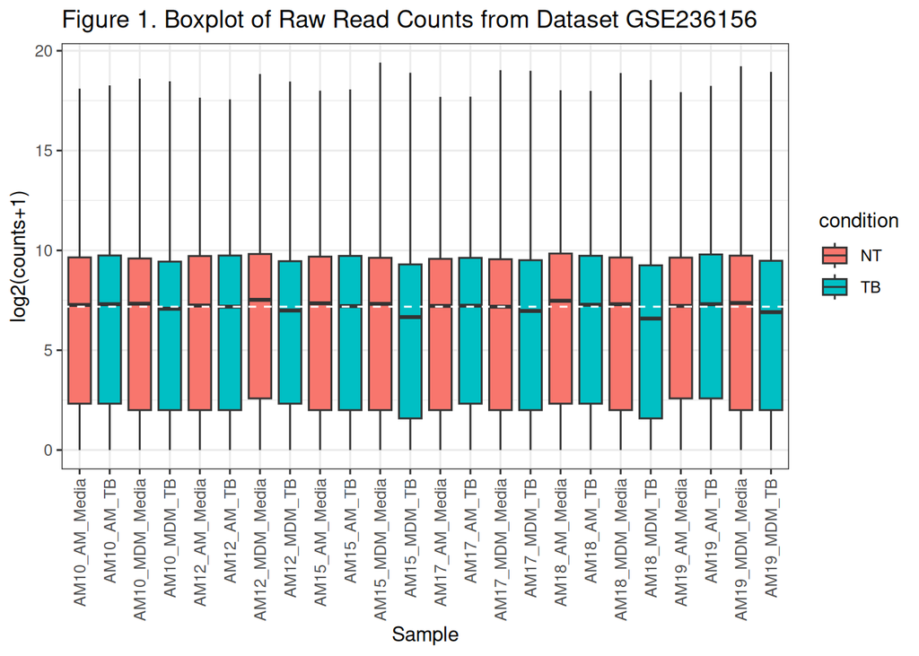

```r
# check boxplot distribution of the current dataset
plot_boxplot(df_cleaned, "Figure 1. Boxplot of Raw Read Counts from Dataset GSE236156")
```

**Figure 1.** Boxplot of the log raw read counts derived from the dataset GSE236156 representing the gene expression distribution. Each vertical label represents a sample. Pink boxes indicate replicates that have not been treated with Mtb, while blue boxes represent samples that have. The white line represents the overall median.

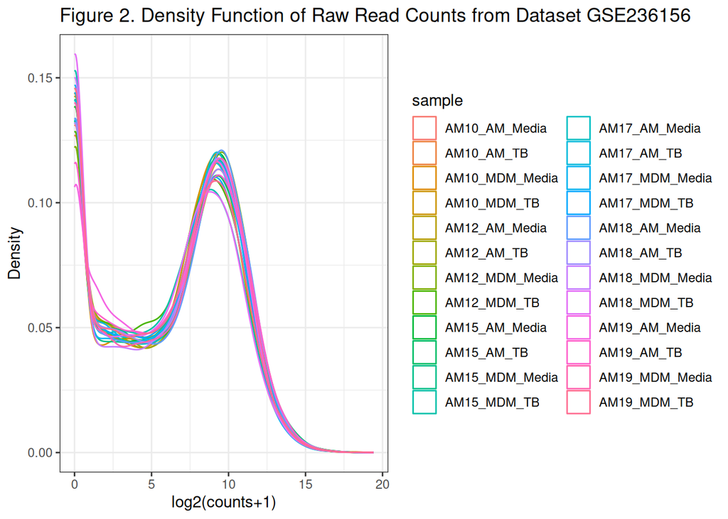

```r
# check density distribution of the current dataset
plot_density(df_cleaned, "Figure 2. Density Function of Raw Read Counts from Dataset GSE236156")
```

**Figure 2.** Density function representation of the log raw read counts derived from the dataset GSE236156 representing the gene expression distribution. Each coloured line represents a sample.

## 3.2 Normalize using TMM

Normalization is a key step in the analysis pipeline, accounting for technical variation that does not stem from differential expression. While our exploration above shows that there is not significant differences in library size, we still see differences likely attributed to inherent technical factors such as batch effects. To account for these differences, we can normalize using the Trimmed Mean of M-values (TMM) method (Robinson and Oshlack 2010). This method scales factors to ensure comparable expression levels across our different samples and accounts for extremes (Singh et al. 2024). This method was selected compared to the Relative Log Expression (RLE) method implemented by DESeq2 (Love et al. 2014) due to shown similar results on real and simulated datasets (Maza 2016) while additionally accounting for library size.

To visualize our normalized data, we use the counts per million (CPM) method. We can use the `edgeR` package (Chen et al. 2025) to do so. We initialize a DGEList object containing information on the study design, normalize using TMM, and visualize after applying the CPM method.

```r
library(edgeR)
library(DESeq2)
```

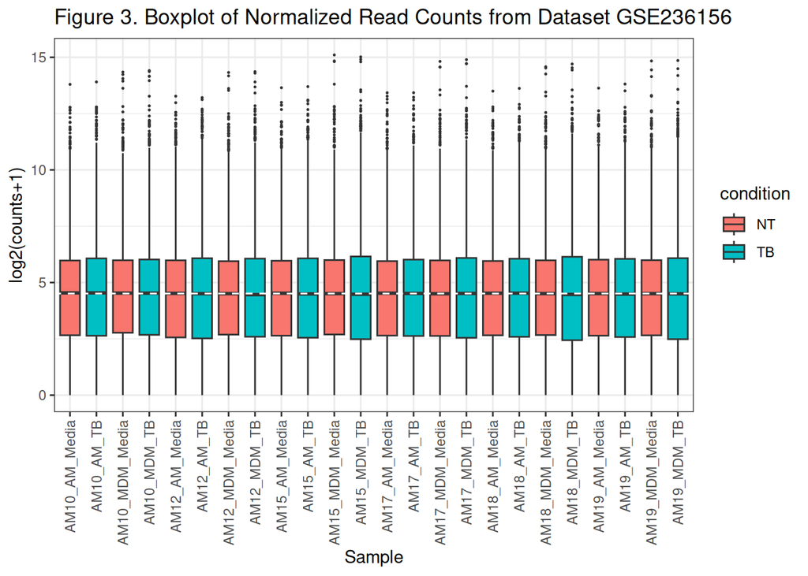

```r
# write as matrix
counts <- as.matrix(df_cleaned)

# create metadata
samples <- colnames(counts)
cellline  <- unlist(lapply(samples, FUN =
                             function(x){unlist(strsplit(x,split = "_"))[2]}))
treatment <- unlist(lapply(samples, FUN =
                             function(x){unlist(strsplit(x,split = "_"))[3]}))
meta <- data.frame(samples, cellline, treatment)

# create DGEList
dge <- edgeR::DGEList(counts = counts)
dge$samples <- cbind(dge$samples, meta)

# create design matrix
design <- model.matrix(~ 0 + treatment + cellline, data = meta)

# filter out lowly expressed genes
dge_f <- dge[edgeR::filterByExpr(dge, design), ]

# normalize using TMM method
dge_f <- edgeR::calcNormFactors(dge_f, method = "TMM")

# apply cpm method
norm_cpm <- edgeR::cpm(dge_f, log = FALSE, prior.count = 1)

plot_boxplot(norm_cpm, "Figure 3. Boxplot of Normalized Read Counts from Dataset GSE236156")
```

**Figure 3.** Boxplot of normalized log read counts from dataset GSE236156 using the TMM and CPM methods representing the gene expression distribution. Each vertical label represents a sample. Pink boxes indicate replicates that have not been treated with Mtb, while blue boxes represent samples that have. The white line represents the overall median.

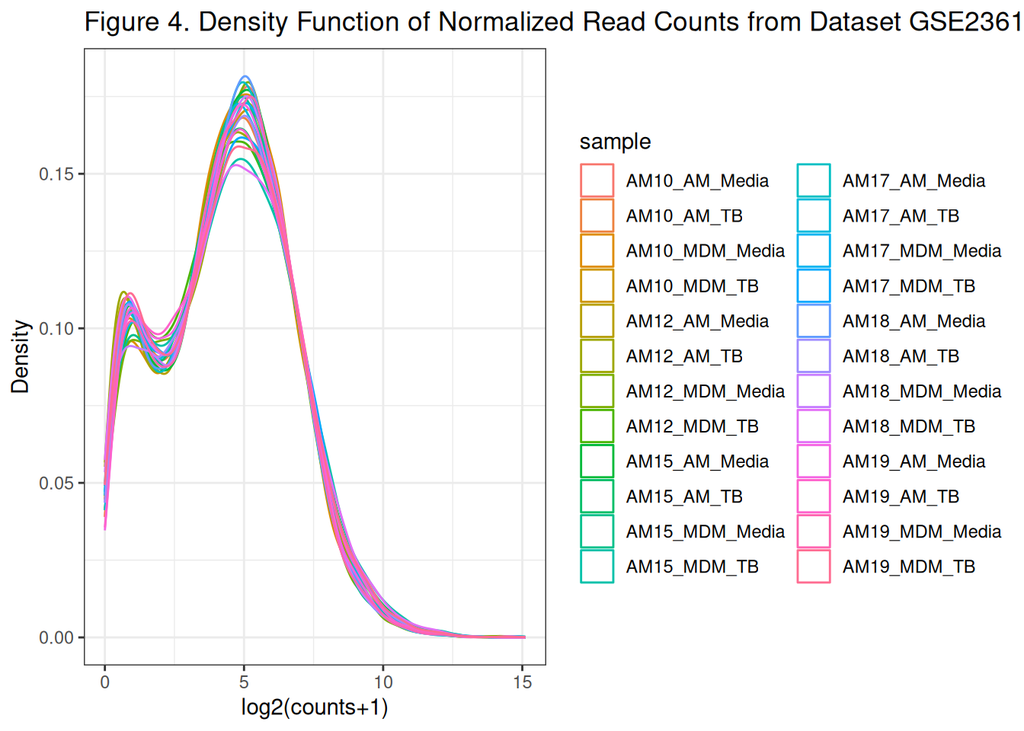

```r
plot_density(norm_cpm, "Figure 4. Density Function of Normalized Read Counts from Dataset GSE236156")
```

From our figures, such as the aligned medians in Figure 3, we can see that normalization has had a consistent effect on the dataset.

## 3.3 Visualize Clustering using MDS

Before we proceed to differential gene expression analysis, we can visualize clustering within the dataset using Multi-Dimensional Scaling (MDS).

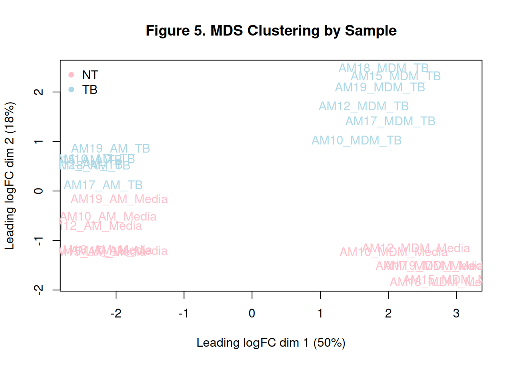

```r
# bind the experimental condition to sample
cond <- sample_cond$condition
dge_f$samples <- cbind(dge_f$samples, cond)

# create a MDS plot clustering samples
plotMDS(dge_f, labels = dge_f$samples$samples, col = ifelse(dge_f$samples$cond == "NT", "pink", "lightblue"), main = "Figure 5. MDS Clustering by Sample")
legend("topleft", legend = levels(factor(dge_f$samples$cond)), col = c("pink", "lightblue"), pch = 16, bty = "n")
```

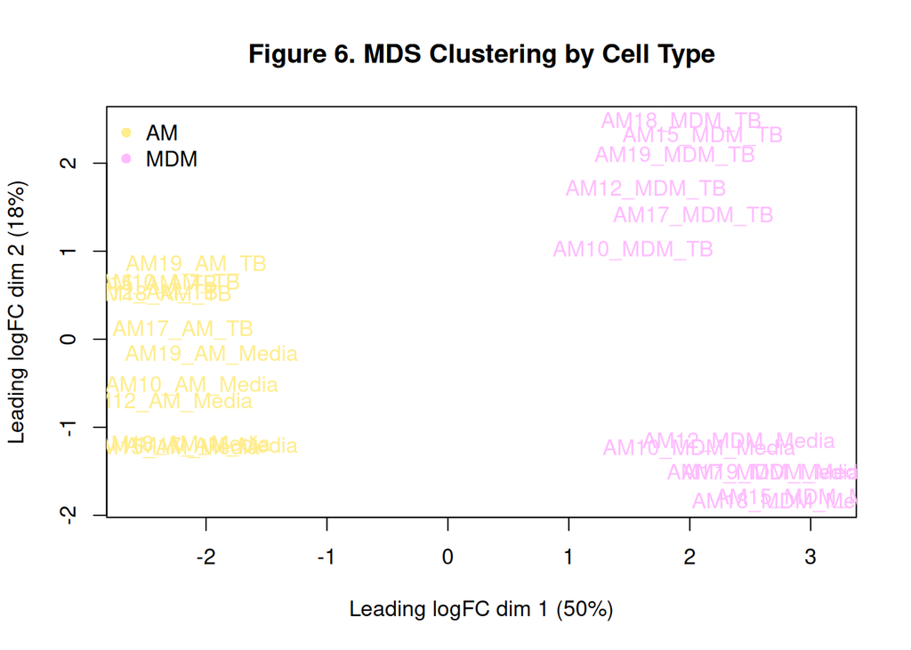

```r
plotMDS(dge_f, labels = dge_f$samples$samples, col = ifelse(dge_f$samples$cellline == "AM", "lightgoldenrod1", "plum1"), main = "Figure 6. MDS Clustering by Cell Type")
legend("topleft", legend = levels(factor(dge_f$samples$cellline)), col = c("lightgoldenrod1", "plum1"), pch = 16, bty = "n")
```

**Figure 6.** MDS plot of dataset GSE236156 clustered by cell Type. Yellow points represent samples using AMs while pink points represent samples using MDMs. Samples are labeled by name.

We can see clear clustering based on experimental condition, particularly along the second axis. However, it is also interesting to note that there is also clustering along cell type, which may show further in our differential gene expression analysis.

# Differential Expression Analysis

## 4.1 Differential Analysis using DESeq2

After normalization, we can now conduct an analysis of differential expression between our two conditions. We can do so using the package `DESeq2` (Love et al. 2014). This was selected because of its suitability for datasets with a moderate sample size (in our case, being 12), compared to similar packages such as `limma` (Ritchie et al. 2015) and `edgeR` (Chen et al. 2025) which is more suitable for smaller sample sizes.

We use the Wald test for the `DESeq` method, which is the default for this method. Multiple hypothesis testing correction is conducted using the Benjamini-Hochberg method, which controls the false discovery rate (FDR) without being overly stringent (Benjamini and Hochberg 1995). We set the p-value cutoff for 0.05 from the default, for more stringent significance.

```r
library(DESeq2)

# create matrix for DESeq using processed dataset
count_mat <- dge_f$counts
stopifnot(all(colnames(count_mat) == meta$sample))

dds <- DESeq2::DESeqDataSetFromMatrix(
  countData = count_mat,
  colData = as.data.frame(meta),
  design = ~ cellline + treatment
)
# apply the default Wald test
dds <- DESeq2::DESeq(dds, test = "Wald")
# extract differential expression analysis results
# additionally apply multiple hypothesis testing correction
tb_vs_media <- DESeq2::results(dds,
                       contrast = c("treatment", "Media", "TB"),
                       alpha = 0.05,
                       pAdjustMethod = "BH",
                       cooksCutoff = TRUE,
                       independentFiltering = TRUE)

# look at summary
tbm_summary <- summary(tb_vs_media)
```

```
##
## out of 12696 with nonzero total read count
## adjusted p-value < 0.05
## LFC > 0 (up)       : 2529, 20%
## LFC < 0 (down)     : 2605, 21%
## outliers [1]       : 21, 0.17%
## low counts [2]     : 0, 0%
## (mean count < 6)
## [1] see 'cooksCutoff' argument of ?results
## [2] see 'independentFiltering' argument of ?results
```

```r
# find significantly differentially expressed genes
tbm_df <- as.data.frame(tb_vs_media)
sig_res <- tbm_df |> filter(!is.na(padj)) |> filter(padj < 0.05 & abs(log2FoldChange) >= 1)

diff_exp <- nrow(sig_res)
```

Using this method, we find strictly differentially expressed gene hits. We define this criteria by limiting for genes where FDR < 0.05 and the log-fold change is greater than or equal to 1, for at least 2-fold change. 965 genes were found to pass this threshold.

## 4.1 Multiple Hypothesis Testing Correction

```r
mhtc <- sum(tb_vs_media$padj < 0.05, na.rm=TRUE)
```

As mentioned above, the Benjamini-Hochberg method was applied for multiple hypothesis testing correction. 5134 genes passed multiple testing correction.

## 4.3 Volcano Plot Visualization

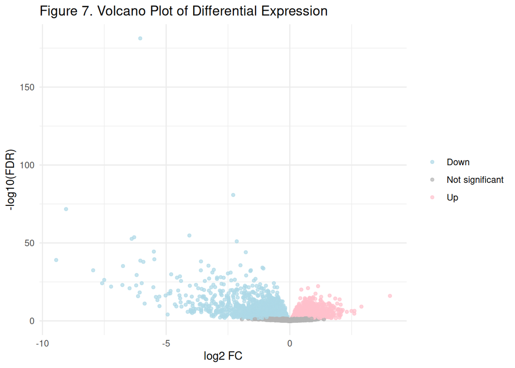

```r
library(tibble)

volcano_plot <- as.data.frame(tb_vs_media) |>
  rownames_to_column("gene") |>
  mutate(
    neglog10p = -log10(pvalue),
    direction = ifelse(!is.na(padj) & padj < 0.05, ifelse(log2FoldChange > 0, "Up", ifelse(log2FoldChange < 0, "Down", "Not significant")), "Not significant")
  )

ggplot(volcano_plot, aes(x = log2FoldChange, y = neglog10p)) +
  geom_point(aes(color = direction), alpha = 0.7, size = 1.2) +
  scale_color_manual(values = c(Up = "pink", Down = "lightblue", `Not significant` = "grey70")) +
  theme_minimal() +
  labs(title = "Figure 7. Volcano Plot of Differential Expression", x = "log2 FC", y = "-log10(FDR)", color = NULL)
```

**Figure 7.** Volcano plot of differential expression. Highlighted points expressed differential expression based on abs(log2-fold change) > 0 and significance in FDR < 0.05.

We can also visualize this plot using our stricter threshold for log-fold change.

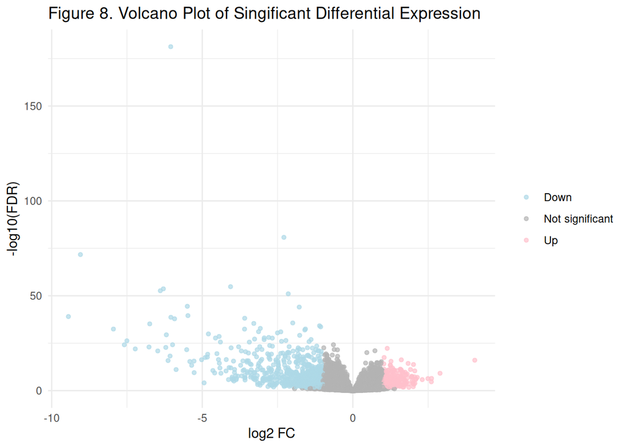

```r
volcano_plot <- as.data.frame(tb_vs_media) |>
  rownames_to_column("gene") |>
  mutate(
    neglog10p = -log10(pvalue),
    direction = ifelse(!is.na(padj) & padj < 0.05, ifelse(log2FoldChange > 1, "Up", ifelse(log2FoldChange < -1, "Down", "Not significant")), "Not significant")
  )

ggplot(volcano_plot, aes(x = log2FoldChange, y = neglog10p)) +
  geom_point(aes(color = direction), alpha = 0.7, size = 1.2) +
  scale_color_manual(values = c(Up = "pink", Down = "lightblue", `Not significant` = "grey70")) +
  theme_minimal() +
  labs(title = "Figure 8. Volcano Plot of Singificant Differential Expression", x = "log2 FC", y = "-log10(FDR)", color = NULL)
```

**Figure 8.** Volcano plot of differential expression. Highlighted points expressed differential expression based on abs(log2-fold change) > 1 and significance in FDR < 0.05.

## 4.4 Heatmap Visualization

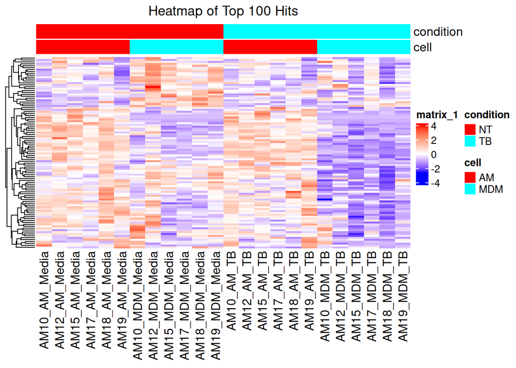

```r
library(ComplexHeatmap)
library(circlize)
# find top hits for expression change
ordered_tmb <- tbm_df[order(abs(tbm_df$log2FoldChange), decreasing = FALSE), ]
top_rows <- rownames(ordered_tmb[1:100, ])

# find counts for these genes
dge_top <- dge_f[top_rows, ]

# color
heatmap_matrix <- t(scale(t(dge_top$counts)))
if(min(heatmap_matrix) == 0){
    heatmap_col = circlize::colorRamp2(c(0, max(heatmap_matrix)),
                      c("white", "red"))
  } else {
    heatmap_col = circlize::colorRamp2(c(min(heatmap_matrix), 0,
        max(heatmap_matrix)), c("blue", "white", "red"))
  }

# create annotation for heatmap
cond_col = rainbow(n = 2)
names(cond_col) <- c("NT", "TB")

cell_col = rainbow(n = 2)
names(cell_col) <- c("AM", "MDM")

hmp_ann <- ComplexHeatmap::HeatmapAnnotation(
  df = data.frame(condition = dge_top$samples$cond, cell = dge_top$samples$cellline),
  col = list(condition = cond_col, cell = cell_col),
  show_legend = TRUE)

# create heatmap showing clustering of treated vs. non-treated samples
current_heatmap <- ComplexHeatmap::Heatmap(as.matrix(heatmap_matrix),
      top_annotation = hmp_ann,
      col=heatmap_col,
      column_title = "Heatmap of Top 100 Hits",
      show_column_names = TRUE,
      show_row_names = FALSE,
      show_heatmap_legend = TRUE,
      column_order = col_order[-1])

current_heatmap
```

# Final Conclusions

## 5.1 Final Dataset and Coverage

The required final dataset is a normalized expression matrix with gene HGNC symbols as row names and numeric expression values across each sample as columns. The final coverage for this dataset is 12,696 genes, which provides a suitable coverage for robust transcriptomic analysis.

```r
# final dataset
final_dataset <- as.matrix(dge_f)

# coverage
coverage <- dim(final_dataset)
```

# Discussion Questions

1. Why is the dataset of interest to you? Please see section 1.1: Experimental information.
2. What are the control and test conditions of the dataset? Please see section 1.1: Experimental information.
3. How many samples in each of the conditions of your dataset? Please see section 1.1: Experimental information.
4. Were there expression values that were not unique for specific genes? How did you handle these? Please see sections 2.3: ID Mapping and 2.4: Data Cleaning.
5. Were there expression values that could not be mapped to current HUGO symbols? Please see sections 2.3: ID Mapping and 2.4: Data Cleaning.
6. Were there any outliers in your dataset? How were they handled in the originating paper? How many outliers were removed? Please see sections 2.2: Initial data exploration and summary and 2.4: Data Cleaning.
7. How did you handle replicates? Please see section 2.2: Initial data exploration and summary.
8. What is the final coverage of your dataset? Please see section 5.1: Final Dataset and Coverage.

# References

Allaire J, Xie Y, Dervieux C, McPherson J, Luraschi J, Ushey K, Atkins A, Wickham H, Cheng J, Chang W, Iannone R (2025). *rmarkdown: Dynamic Documents for R*. R package version 2.30, https://github.com/rstudio/rmarkdown.

Benjamini, Y., and Hochberg, Y. (1995). Controlling the false discovery rate: a practical and powerful approach to multiple testing. Journal of the Royal Statistical Society Series B, 57, 289–300. doi:10.1111/j.2517-6161.1995.tb02031.x.

BioMart and Bioconductor: a powerful link between biological databases and microarray data analysis. Steffen Durinck, Yves Moreau, Arek Kasprzyk, Sean Davis, Bart De Moor, Alvis Brazma and Wolfgang Huber, Bioinformatics 21, 3439-3440 (2005).

Chen Y, Chen L, Lun ATL, Baldoni P, Smyth GK (2025). “edgeR v4: powerful differential analysis of sequencing data with expanded functionality and improved support for small counts and larger datasets.” Nucleic Acids Research, 53(2), gkaf018. doi:10.1093/nar/gkaf018.

Davis S, Meltzer P (2007). “GEOquery: a bridge between the Gene Expression Omnibus (GEO) and BioConductor.” *Bioinformatics*, *14*, 1846-1847. doi:10.1093/bioinformatics/btm254 https://doi.org/10.1093/bioinformatics/btm254.

Dill-McFarland, K. A., Simmons, J. D., Peterson, G. J., Nguyen, F. K., Campo, M., Benchek, P., Stein, C. M., Vaisar, T., Mayanja-Kizza, H., Boom, W. H., & Hawn, T. R. (2024). Epigenetic programming of host lipid metabolism associated with resistance to TST/IGRA conversion after exposure to Mycobacterium tuberculosis. mSystems, 9(9), e0062824. https://doi.org/10.1128/msystems.00628-24

Gu, Z. (2016) Complex heatmaps reveal patterns and correlations in multidimensional genomic data. Bioinformatics.

Gu, Z. (2014) circlize implements and enhances circular visualization in R. Bioinformatics.

Love, M.I., Huber, W., Anders, S. Moderated estimation of fold change and dispersion for RNA-seq data with DESeq2 Genome Biology 15(12):550 (2014)

Maza E. (2016). In Papyro Comparison of TMM (edgeR), RLE (DESeq2), and MRN Normalization Methods for a Simple Two-Conditions-Without-Replicates RNA-Seq  
Experimental Design. Frontiers in genetics, 7, 164. https://doi.org/10.3389/fgene.2016.00164

R Core Team (2025). *R: A Language and Environment for Statistical Computing*. R Foundation for Statistical Computing, Vienna, Austria. https://www.R-project.org/.

Ritchie, M.E., Phipson, B., Wu, D., Hu, Y., Law, C.W., Shi, W., and Smyth, G.K. (2015). limma powers differential expression analyses for RNA-sequencing and microarray studies. Nucleic Acids Research 43(7), e47.

Robinson M. D., Oshlack A. (2010). A scaling normalization method for differential expression analysis of RNA-seq data. Genome Biol. 11:R25. 10.1186/gb-2010-11-3-r25

Seal RL, Braschi B, Gray K, Jones TEM, Tweedie S, Haim-Vilmovsky L, Bruford EA. Genenames.org: the HGNC resources in 2023. Nucleic Acids Res. PMID: 36243972 DOI: 10.1093/nar/gkac888

Wickham H, François R, Henry L, Müller K, Vaughan D (2026). *dplyr: A Grammar of Data Manipulation*. R package version 1.2.0, https://dplyr.tidyverse.org.

Wickham H, Vaughan D, Girlich M (2025). *tidyr: Tidy Messy Data*. doi:10.32614/CRAN.package.tidyr https://doi.org/10.32614/CRAN.package.tidyr, R package version 1.3.2, https://CRAN.R-project.org/package=tidyr.

Wickham H. ggplot2: Elegant Graphics for Data Analysis. Springer-Verlag New York, 2016.